# SpatialStatitics_GroupAssignments

Asyifa, Aufa

2026-06-10

# Insert Library

```r
library(readxl)
library(spdep)
set.seed(123)
```

# Read Data

```r
data <- read_excel("data_spatial.xlsx")
head(data)
```

```
## # A tibble: 6 × 6
##   Provinsi             Y    X1     X2 latitude longitude
##   <chr>            <dbl> <dbl>  <dbl>    <dbl>     <dbl>
## 1 Aceh              70.4 10811  5555.    4.70       96.7
## 2 Sumatera Utara    70.3 11460 15588.    2.12       99.5
## 3 Sumatera Barat    70.3 11718  5836.   -0.740     101.
## 4 Riau              72.5 11857  6728.    0.293     102.
## 5 Jambi             72.0 11621  3724.   -1.61      104.
## 6 Sumatera Selatan  70.9 12015  8837.   -3.32      104.
```

Y = Umur Harapan Hidup Saat Lahir

X1 = Pengeluaran per Kapita (Ribu Rupiah/Orang/Tahun)

X2 = Jumlah Penduduk (Ribu)

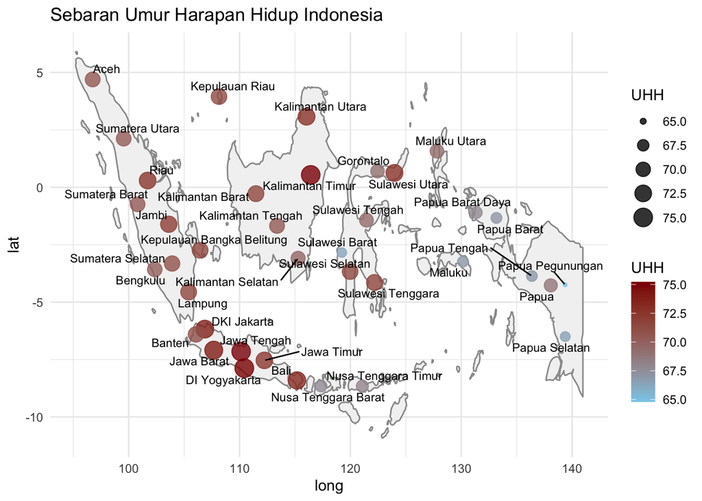

```r
library(ggplot2)
library(maps)
library(ggrepel)

world <- map_data("world")

ggplot() +
  geom_polygon(
    data = subset(world, region == "Indonesia"),
    aes(
      x = long,
      y = lat,
      group = group
    ),
    fill = "grey95",
    color = "grey60"
  ) +
  geom_point(
    data = data,
    aes(
      x = longitude,
      y = latitude,
      color = Y,
      size = Y
    ),
    alpha = 0.8
  ) +
  scale_color_gradient(
    low = "skyblue",
    high = "darkred"
  ) +
  labs(
    title = "Sebaran Umur Harapan Hidup Indonesia",
    color = "UHH",
    size = "UHH"
  ) +
  geom_text_repel(
    data = data,
    aes(
      longitude,
      latitude,
      label = Provinsi
    ),
    size = 3
  ) +
  theme_minimal()
```

Berdasarkan peta sebaran UHH, terlihat bahwa provinsi-provinsi di Pulau Jawa cenderung memiliki nilai UHH yang lebih tinggi dibandingkan wilayah Indonesia bagian timur. Hal ini ditunjukkan oleh warna yang lebih gelap pada DKI Jakarta, Jawa Barat, DI Yogyakarta, Jawa Tengah, dan Jawa Timur.

Sebaliknya, beberapa provinsi di wilayah Papua menunjukkan nilai UHH yang relatif lebih rendah yang ditunjukkan oleh warna yang lebih terang. Perbedaan pola ini mengindikasikan adanya ketimpangan kondisi kesehatan dan kesejahteraan antarwilayah di Indonesia.

Secara visual juga terlihat bahwa provinsi-provinsi dengan nilai UHH tinggi cenderung berdekatan satu sama lain, begitu pula dengan provinsi yang memiliki nilai UHH rendah.

# Koordinat

```r
coords <- cbind(
  data$longitude,
  data$latitude
)
coords <- jitter(coords)
```

# K-Nearest Neighbor

```r
knn <- knearneigh(coords, k = 4)
```

# Neighbor list

```r
nb <- knn2nb(knn)
nb
```

```
## Neighbour list object:
## Number of regions: 38
## Number of nonzero links: 152
## Percentage nonzero weights: 10.52632
## Average number of links: 4
## Non-symmetric neighbours list
```

# Membentuk Spatial Weight Matrix

```r
listw <- nb2listw(nb, style="W")
```

## Global Moran’s I pada Y

H0 : tidak ada dependency spatial pada variable respon H1 : Ada dependecy spatial yang positif pada variable respon

```r
global_moran <- moran.test(
  data$Y,
  listw
)
global_moran
```

```
##
##  Moran I test under randomisation
##
## data:  data$Y
## weights: listw
##
## Moran I statistic standard deviate = 5.8834, p-value = 2.01e-09
## alternative hypothesis: greater
## sample estimates:
## Moran I statistic       Expectation          Variance
##        0.57035709       -0.02702703        0.01030980
```

Artinya, provinsi yang memiliki nilai UHH tinggi cenderung berdekatan dengan provinsi lain yang juga memiliki nilai UHH tinggi. Sebaliknya, provinsi dengan UHH rendah cenderung berdekatan dengan provinsi yang memiliki UHH rendah. Dengan kata lain, terdapat pola pengelompokan (clustering) secara spasial pada data UHH di Indonesia.

# Local Moran’s I (LISA) pada Y

H0 : tidak ada dependency spatial pada variable respon H1 : Ada dependecy spatial yang positif pada variable respon

```r
local_moran <- localmoran(
  data$Y,
  listw
)
local_moran
```

```
##              Ii          E.Ii       Var.Ii        Z.Ii Pr(z != E(Ii))
## 1  -0.008654811 -2.221727e-05 0.0001934711 -0.62063076   0.5348425936
## 2  -0.028788011 -2.223727e-04 0.0019360651 -0.64920814   0.5162038496
## 3  -0.020146583 -1.374777e-04 0.0011970372 -0.57832750   0.5630430337
## 4   0.054600177 -1.635045e-02 0.1400571386  0.18958485   0.8496344573
## 5   0.106344602 -9.462027e-03 0.0816188292  0.40535753   0.6852147278
## 6   0.048538498 -7.033018e-04 0.0061202788  0.62943127   0.5290667489
## 7  -0.039598252 -5.989472e-04 0.0052127080 -0.54016342   0.5890843403
## 8   0.194712782 -3.950439e-03 0.0342658373  1.07321516   0.2831745907
## 9   0.230521193 -3.870719e-03 0.0335770384  1.27914986   0.2008442884
## 10  0.151284597 -2.141812e-03 0.0186116656  1.12462440   0.2607482312
## 11  1.193713350 -4.576176e-02 0.3802721772  2.00997443   0.0444338948
## 12  1.735284247 -5.137851e-02 0.4244333735  2.74244434   0.0060983784
## 13  2.232951835 -7.923438e-02 0.6353276922  2.90084093   0.0037216275
## 14  2.328297622 -8.998264e-02 0.7130885205  2.86374872   0.0041865998
```

[output cut: 68 more lines]

Berdasarkan hasil uji Local Moran’s I, provinsi yang memiliki p-value < 0.05 menunjukkan adanya autokorelasi spasial lokal yang signifikan. Artinya, nilai Umur Harapan Hidup (UHH) pada provinsi tersebut memiliki keterkaitan yang signifikan dengan nilai UHH pada wilayah-wilayah di sekitarnya.

Hasil menunjukkan bahwa DKI Jakarta (p-value = 0.0444), Jawa Barat (p-value = 0.0061), Jawa Tengah (p-value = 0.0037), DI Yogyakarta (p-value = 0.0042), dan Jawa Timur (p-value = 0.0016) memiliki autokorelasi spasial lokal yang signifikan. Selain itu, Maluku (p-value = 0.0217), Papua Barat (p-value = 0.0155), Papua Barat Daya (p-value = 0.0153), Papua (p-value = 0.0007), Papua Selatan (p-value = 0.0021), Papua Tengah (p-value = 0.0017), dan Papua Pegunungan (p-value = 0.0041) juga menunjukkan autokorelasi spasial lokal yang signifikan.

Sebaliknya, provinsi-provinsi lain memiliki p-value > 0.05, sehingga tidak terdapat bukti yang cukup untuk menyatakan adanya autokorelasi spasial lokal yang signifikan pada wilayah tersebut.

Secara keseluruhan, hasil ini menunjukkan bahwa hanya beberapa wilayah tertentu yang membentuk pola pengelompokan spasial yang signifikan, terutama di Pulau Jawa serta kawasan Maluku dan Papua.

```r
# Jadikan dataframe
hasil_lisa <- data.frame(
  Provinsi = data$Provinsi,
  P_Value = local_moran[,5],
  Cluster = attr(local_moran, "quadr")[,3]
)

# Ambil yang signifikan saja
dependensi_spasial <- subset(hasil_lisa, P_Value < 0.05)

dependensi_spasial
```

```
##            Provinsi      P_Value   Cluster
## 11      DKI Jakarta 0.0444338948 High-High
## 12       Jawa Barat 0.0060983784 High-High
## 13      Jawa Tengah 0.0037216275 High-High
## 14    DI Yogyakarta 0.0041865998 High-High
## 15       Jawa Timur 0.0016379678 High-High
## 31           Maluku 0.0216881654   Low-Low
## 33      Papua Barat 0.0155456695   Low-Low
## 34 Papua Barat Daya 0.0152832684   Low-Low
## 35            Papua 0.0006551554   Low-Low
## 36    Papua Selatan 0.0021048425   Low-Low
## 37     Papua Tengah 0.0016512314   Low-Low
## 38 Papua Pegunungan 0.0040608959   Low-Low
```

Hasil LISA menunjukkan bahwa terdapat beberapa provinsi yang memiliki dependensi spasial signifikan.

Kelompok High-High terdiri dari DKI Jakarta, Jawa Barat, Jawa Tengah, DI Yogyakarta, dan Jawa Timur. Provinsi-provinsi tersebut memiliki nilai UHH yang tinggi dan dikelilingi oleh provinsi lain yang juga memiliki nilai UHH tinggi.

Sementara itu, kelompok Low-Low terdiri dari Maluku, Papua Barat, Papua Barat Daya, Papua, Papua Selatan, Papua Tengah, dan Papua Pegunungan. Provinsi-provinsi tersebut memiliki nilai UHH yang relatif rendah dan berada di sekitar wilayah yang juga memiliki nilai UHH rendah.

Temuan ini menunjukkan adanya pengelompokan wilayah dengan karakteristik UHH yang mirip secara geografis.

Untuk lebih jelasnya, bisa dilihat pada visualisasi dibawah ini.

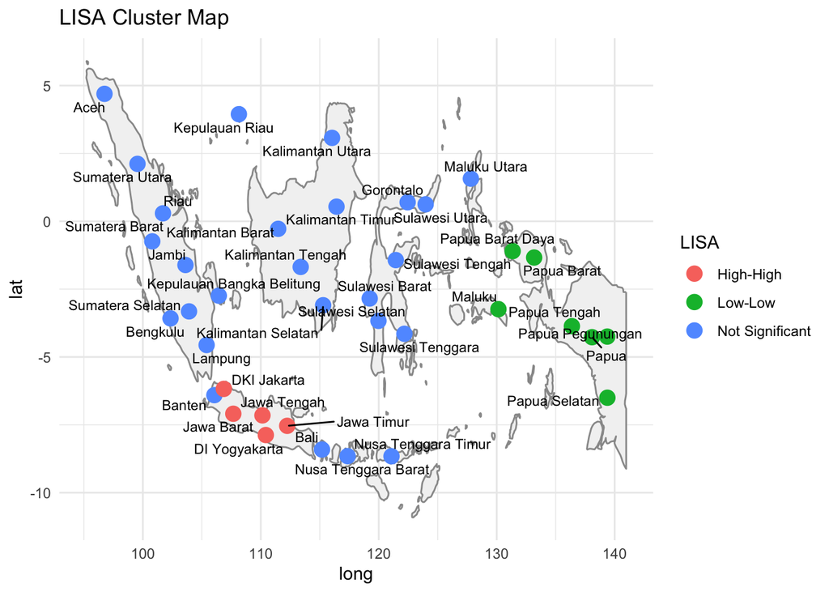

```r
hasil_lisa$LISA <- "Not Significant"

hasil_lisa$LISA[
  hasil_lisa$P_Value < 0.05
] <- as.character(
  hasil_lisa$Cluster[
    hasil_lisa$P_Value < 0.05
  ]
)

map_lisa <- merge(
  data,
  hasil_lisa,
  by = "Provinsi"
)

ggplot() +
  geom_polygon(
    data = subset(world, region == "Indonesia"),
    aes(
      long,
      lat,
      group = group
    ),
    fill = "grey95",
    color = "grey60"
  ) +
  geom_point(
    data = map_lisa,
    aes(
      longitude,
      latitude,
      color = LISA
    ),
    size = 4
  ) +
  geom_text_repel(
    data = map_lisa,
    aes(
      longitude,
      latitude,
      label = Provinsi
    ),
    size = 3
  ) +
  labs(
    title = "LISA Cluster Map"
  ) +
  theme_minimal()
```

Berdasarkan peta LISA Cluster Map, terlihat adanya pengelompokan wilayah yang memiliki karakteristik UHH yang serupa.

Secara keseluruhan, peta LISA memperlihatkan bahwa pengelompokan UHH di Indonesia tidak terjadi secara acak, melainkan membentuk klaster wilayah dengan karakteristik yang mirip. Temuan ini memperkuat hasil Global Moran’s I yang menunjukkan adanya dependensi spasial pada variabel Umur Harapan Hidup Saat Lahir.

# Bikin Model OLS

```r
model_ols <- lm(Y ~ X1 + X2, data = data)
summary(model_ols)
```

```
##
## Call:
## lm(formula = Y ~ X1 + X2, data = data)
##
## Residuals:
##     Min      1Q  Median      3Q     Max
## -2.8700 -1.0322 -0.1277  1.0097  3.6525
##
## Coefficients:
##              Estimate Std. Error t value Pr(>|t|)
## (Intercept) 6.204e+01  1.347e+00  46.068  < 2e-16 ***
## X1          6.850e-04  1.160e-04   5.903 1.04e-06 ***
## X2          7.209e-05  2.523e-05   2.857  0.00715 **
## ---
## Signif. codes:  0 '***' 0.001 '**' 0.01 '*' 0.05 '.' 0.1 ' ' 1
##
## Residual standard error: 1.699 on 35 degrees of freedom
## Multiple R-squared:  0.6002, Adjusted R-squared:  0.5774
## F-statistic: 26.28 on 2 and 35 DF,  p-value: 1.075e-07
```

Nilai p-value = 1.075e-07 < 0.05 menunjukkan bahwa variabel Pengeluaran per Kapita (X1) dan Jumlah Penduduk (X2) secara bersama-sama berpengaruh signifikan terhadap Umur Harapan Hidup Saat Lahir (Y).

- X1: Setiap kenaikan pengeluaran per kapita sebesar Rp1.000 per orang per tahun diperkirakan akan meningkatkan UHH sebesar 0.000685 tahun, dengan asumsi variabel lain konstan. Hal ini menunjukkan bahwa semakin tinggi tingkat pengeluaran masyarakat, maka kualitas hidup dan harapan hidup masyarakat cenderung meningkat.
- X2: Setiap kenaikan jumlah penduduk sebesar 1 ribu jiwa diperkirakan akan meningkatkan UHH sebesar 0.000072 tahun, dengan asumsi variabel lain konstan.

# Uji Asumsi

## 1. Normalitas Residual

H0 : Residual Berdistribusi Normal H1 : Residual Tidak Berdistribusi Normal

```r
shapiro.test(residuals(model_ols))
```

```
##
##  Shapiro-Wilk normality test
##
## data:  residuals(model_ols)
## W = 0.97388, p-value = 0.5062
```

p-value = 0.5062 > 0.05, maka gagal tolak H0. Sehingga residual berdistribusi normal.

## 2. Homoskedastisitas

H0 : Tidak Terjadi Heteroskedastisitas H1 : Terjadi Heteroskedastisitas

```r
library(lmtest)
bptest(model_ols)
```

```
##
##  studentized Breusch-Pagan test
##
## data:  model_ols
## BP = 2.6905, df = 2, p-value = 0.2605
```

p-value = 0.2605 > 0.05, maka gagal tolak H0. Sehingga tidak terdapat heteroskedastisitas.

## 3. Autokorelasi

H0: Tidak Terdapat Autokorelasi residual H1: Terdapat Autokorelasi residual

```r
dwtest(model_ols)
```

```
##
##  Durbin-Watson test
##
## data:  model_ols
## DW = 1.4143, p-value = 0.02228
## alternative hypothesis: true autocorrelation is greater than 0
```

p-value = 0.02228 < 0.05, maka tolak H0.Sehingga terdapat autokorelasi.

Hal ini menunjukkan bahwa residual antar wilayah masih saling berkorelasi sehingga model OLS kurang mampu menangkap pengaruh spasial yang terdapat pada data.

Dengan ditemukannya autokorelasi pada residual model OLS, analisis dilanjutkan menggunakan pendekatan regresi spasial. Selanjutnya dilakukan uji Lagrange Multiplier (LM Test) untuk menentukan jenis model spasial yang paling sesuai digunakan dalam penelitian ini.

# LM Test pada Regresi Spatial

```r
rs_test <- lm.RStests(
  model_ols,
  listw,
  test = c("RSlag", "RSerr", "adjRSerr", "adjRSlag")
)
rs_test
```

```
##
##  Rao's score (a.k.a Lagrange multiplier) diagnostics for spatial
##  dependence
##
## data:
## model: lm(formula = Y ~ X1 + X2, data = data)
## test weights: listw
##
## RSlag = 2.1212, df = 1, p-value = 0.1453
##
##
##  Rao's score (a.k.a Lagrange multiplier) diagnostics for spatial
##  dependence
##
## data:
## model: lm(formula = Y ~ X1 + X2, data = data)
## test weights: listw
##
## RSerr = 0.0174, df = 1, p-value = 0.8951
##
##
##  Rao's score (a.k.a Lagrange multiplier) diagnostics for spatial
##  dependence
##
## data:
## model: lm(formula = Y ~ X1 + X2, data = data)
## test weights: listw
##
## adjRSerr = 2.5961, df = 1, p-value = 0.1071
##
##
##  Rao's score (a.k.a Lagrange multiplier) diagnostics for spatial
##  dependence
##
## data:
## model: lm(formula = Y ~ X1 + X2, data = data)
## test weights: listw
##
## adjRSlag = 4.6999, df = 1, p-value = 0.03016
```

```r
rs_df <- data.frame(
  Test = names(rs_test),
  Statistic = sapply(rs_test, function(x) x$statistic),
  P_Value = sapply(rs_test, function(x) x$p.value)
)

rs_df
```

```
##                       Test  Statistic    P_Value
## RSlag.RSlag          RSlag 2.12119614 0.14527305
## RSerr.RSerr          RSerr 0.01739981 0.89505679
## adjRSerr.adjRSerr adjRSerr 2.59614920 0.10712371
## adjRSlag.adjRSlag adjRSlag 4.69994553 0.03016357
```

## RSlag

H0 : Tidak terdapat ketergantungan spasial pada var dependen H1: terdapat ketergantungan spasial

## RSerr

H0 : tidak ada ketergantungan spasial pada error H1 : terdapat ketergantungan spasial

## adjRserr

H0: tidak terdapat ketergantungan spasial error setelah kontrol kemungkinan spatial lag H1: terdapat ketergantungan spasial error setelah mengontrol kemungkinan spatial lag

## adjRSlag

H0: tidak ada ketergantungan spasial lag setelah mengontrol kemungkinan spatial error H1: terdapat ketergantungan spasial lag setelah mengontrol kemungkinan spatial error

# Model SAR

```r
library(spatialreg)
sar <- lagsarlm(
  Y ~ X1 + X2,
  data = data,
  listw = listw
)

summary(sar)
```

```
##
## Call:lagsarlm(formula = Y ~ X1 + X2, data = data, listw = listw)
##
## Residuals:
##       Min        1Q    Median        3Q       Max
## -3.152699 -1.091845 -0.074944  0.803606  3.675116
##
## Type: lag
## Coefficients: (asymptotic standard errors)
##               Estimate Std. Error z value  Pr(>|z|)
## (Intercept) 4.4731e+01 1.0127e+01  4.4172 9.999e-06
## X1          5.6074e-04 1.2153e-04  4.6139 3.952e-06
## X2          4.8852e-05 2.6483e-05  1.8446   0.06509
##
## Rho: 0.2679, LR test value: 2.3985, p-value: 0.12145
## Asymptotic standard error: 0.15315
##     z-value: 1.7493, p-value: 0.080235
## Wald statistic: 3.0601, p-value: 0.080235
##
## Log likelihood: -71.30254 for lag model
## ML residual variance (sigma squared): 2.4577, (sigma: 1.5677)
## Number of observations: 38
## Number of parameters estimated: 5
## AIC: 152.61, (AIC for lm: 153)
## LM test for residual autocorrelation
## test value: 1.7129, p-value: 0.19061
```

# Model SEM

```r
sem <- errorsarlm(
  Y ~ X1 + X2,
  data = data,
  listw = listw
)

summary(sem)
```

```
##
## Call:errorsarlm(formula = Y ~ X1 + X2, data = data, listw = listw)
##
## Residuals:
##      Min       1Q   Median       3Q      Max
## -2.84009 -1.03881 -0.09074  0.97654  3.72447
##
## Type: error
## Coefficients: (asymptotic standard errors)
##               Estimate Std. Error z value  Pr(>|z|)
## (Intercept) 6.1843e+01 1.2650e+00 48.8865 < 2.2e-16
## X1          7.0198e-04 1.0990e-04  6.3877 1.684e-10
## X2          7.2125e-05 2.3834e-05  3.0261  0.002478
##
## Lambda: -0.062866, LR test value: 0.033956, p-value: 0.8538
## Asymptotic standard error: 0.25069
##     z-value: -0.25077, p-value: 0.80199
## Wald statistic: 0.062886, p-value: 0.80199
##
## Log likelihood: -72.48483 for error model
## ML residual variance (sigma squared): 2.6548, (sigma: 1.6294)
## Number of observations: 38
## Number of parameters estimated: 5
## AIC: 154.97, (AIC for lm: 153)
```

# Model SARMA

```r
library(spatialreg)

sarma <- sacsarlm(
  Y ~ X1 + X2,
  data = data,
  listw = listw
)

summary(sarma)
```

```
##
## Call:sacsarlm(formula = Y ~ X1 + X2, data = data, listw = listw)
##
## Residuals:
##       Min        1Q    Median        3Q       Max
## -3.130246 -0.961054 -0.080485  0.844971  3.320137
##
## Type: sac
## Coefficients: (asymptotic standard errors)
##               Estimate Std. Error z value  Pr(>|z|)
## (Intercept) 3.7189e+01 1.2148e+01  3.0614 0.0022031
## X1          5.5801e-04 1.4380e-04  3.8805 0.0001043
## X2          3.4702e-05 2.6311e-05  1.3189 0.1872082
##
## Rho: 0.37688
## Asymptotic standard error: 0.19118
##     z-value: 1.9713, p-value: 0.048687
## Lambda: -0.48073
## Asymptotic standard error: 0.393
##     z-value: -1.2232, p-value: 0.22125
##
## LR test value: 4.121, p-value: 0.12739
##
## Log likelihood: -70.44132 for sac model
## ML residual variance (sigma squared): 2.2197, (sigma: 1.4899)
## Number of observations: 38
## Number of parameters estimated: 6
## AIC: 152.88, (AIC for lm: 153)
```

# Comparison Model

```r
comparison <- data.frame(
  Model = c("OLS", "SAR", "SEM", "SARMA"),
  AIC = c(
    AIC(model_ols),
    AIC(sar),
    AIC(sem),
    AIC(sarma)
  )
)

comparison <- comparison[order(comparison$AIC), ]
comparison
```

```
##   Model      AIC
## 2   SAR 152.6051
## 4 SARMA 152.8826
## 1   OLS 153.0036
## 3   SEM 154.9697
```